# Standard Errors

Albert Y. Kim

Wed Nov 30, 2016

Let’s revisit the OkCupid profile data. Run the following in your console:

```r
library(mosaic)
library(dplyr)
library(ggplot2)

library(okcupiddata)
data(profiles)

# Remove individuals with no listed height
profiles <- profiles %>%
  filter(!is.na(height))
```

We take many, many, many samples of size 5 and then take the sample mean:

```r
n <- 5
samples_5 <- do(10000) *
  mean(resample(profiles$height, size=n, replace=TRUE))
samples_5 <- samples_5 %>%
  as_data_frame()
```

We take many, many, many samples of size 50 and then take the sample mean:

```r
n <- 50
samples_50 <- do(10000) *
  mean(resample(profiles$height, size=n, replace=TRUE))
samples_50 <- samples_50 %>%
  as_data_frame()
```

## Learning Checks

1. Explicity compute the **standard error** when taking samples of size `n=5` and `n=50`.
2. Discuss with your peers **why** they matter in any study that involves some kind of sampling.

#### LC1

**In General**: The standard error is the standard deviation of the point estimate. In this case, it is the value that quantifies how much the sample means vary by.

**In Our Case**: If we take a sample of 5 OkCupid users and compute the (sample) mean height, are we going to get the same value each time? No. The SE measures this sample mean varies.

**Mathematically**: You can derive the standard error mathematically, but this is for a more advanced class in Probability/Statistics. See Advanced section below.

**Computationally**: It is the standard deviation of our 10000 sample means:

```r
samples_5 %>%
  summarise(SE = sd(mean))
```

```
## # A tibble: 1 × 1
##         SE
##      <dbl>
## 1 1.803266
```

```r
samples_50 %>%
  summarise(SE = sd(mean))
```

```
## # A tibble: 1 × 1
##          SE
##       <dbl>
## 1 0.5730157
```

**Results**:

1. The SE with `n=50` is smaller i.e.
2. The sample mean $\overline{x}$ are less variable when `n=50`
3. The sample mean $\overline{x}$ is more precise when `n=50`
4. **Our estimates are on average better when `n=50`**

**Visualization**: Recall, the sampling distribution is the distribution of the point estimate. We see that for `n=50`

- the distribution is narrower i.e.
- it has a smaller standard deviation i.e.
- the standard error is smaller
- **Our estimates are on average better when `n=50`. Bigger sample size is better.**

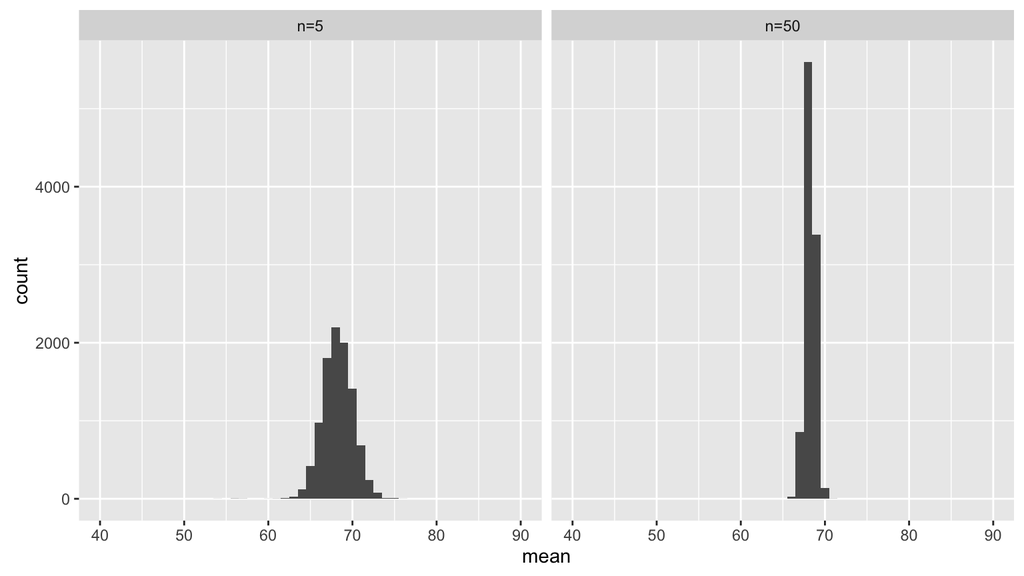

#### LC2

From sample to sample, your point estimate, in this case the sample mean, will vary! i.e. there is **uncertainty**. How much uncertainty? The SE quantifies this!

#### Advanced

If you’re curious, the mathematically/probabilistically derived formula for the Standard Error is $\mbox{SE}_{\overline{x}} = \frac{\sigma}{\sqrt{n}}$ where

- $\sigma$ is the **population standard deviation**: the true standard deviation of the 60K heights (and not the standard deviation of the 10000 many, many, many sample means)
- $n$ is the sample size (and not the many, many, many number of times `n`)

Note how $n$ is in the denominator. So

- As $n \longrightarrow \infty$, we have $\mbox{SE}_{\overline{x}} \longrightarrow 0$ i.e.
- As $n \longrightarrow \infty$, there is no uncertainty in our estimate $\overline{x}$ of $\mu$, we know the answer exactly!

In our case since $\sigma$ = `sd(profiles$height)` = 3.995, we have for

- `n=5`: SE = $\frac{3.995}{\sqrt{5}} = 1.787$
- `n=50`: SE = $\frac{3.995}{\sqrt{50}} = 0.564$

Note these are pretty close to the computationally computed values above. Why is $\mbox{SE}_{\overline{x}} = \frac{\sigma}{\sqrt{n}}$? You need the tools from Probability MATH 310 to show this.